# hw4

```python
import pandas as pd
import matplotlib.pyplot as plt
import seaborn as sb
from sklearn.datasets import fetch_california_housing, load_iris

california_housing = fetch_california_housing()
housing_df = pd.DataFrame(california_housing.data, columns=california_housing.feature_names)
housing_df['target'] = california_housing.target

irisLoad = load_iris()

iris_df = pd.DataFrame(irisLoad.data, columns=irisLoad.feature_names)
iris_df['target'] = irisLoad.target
```

```python
housing_df
```

|  | MedInc | HouseAge | AveRooms | AveBedrms | Population | AveOccup | Latitude | Longitude | target |
| --- | --- | --- | --- | --- | --- | --- | --- | --- | --- |
| 0 | 8.3252 | 41.0 | 6.984127 | 1.023810 | 322.0 | 2.555556 | 37.88 | -122.23 | 4.526 |
| 1 | 8.3014 | 21.0 | 6.238137 | 0.971880 | 2401.0 | 2.109842 | 37.86 | -122.22 | 3.585 |
| 2 | 7.2574 | 52.0 | 8.288136 | 1.073446 | 496.0 | 2.802260 | 37.85 | -122.24 | 3.521 |
| 3 | 5.6431 | 52.0 | 5.817352 | 1.073059 | 558.0 | 2.547945 | 37.85 | -122.25 | 3.413 |
| 4 | 3.8462 | 52.0 | 6.281853 | 1.081081 | 565.0 | 2.181467 | 37.85 | -122.25 | 3.422 |
| ... | ... | ... | ... | ... | ... | ... | ... | ... | ... |
| 20635 | 1.5603 | 25.0 | 5.045455 | 1.133333 | 845.0 | 2.560606 | 39.48 | -121.09 | 0.781 |
| 20636 | 2.5568 | 18.0 | 6.114035 | 1.315789 | 356.0 | 3.122807 | 39.49 | -121.21 | 0.771 |
| 20637 | 1.7000 | 17.0 | 5.205543 | 1.120092 | 1007.0 | 2.325635 | 39.43 | -121.22 | 0.923 |
| 20638 | 1.8672 | 18.0 | 5.329513 | 1.171920 | 741.0 | 2.123209 | 39.43 | -121.32 | 0.847 |
| 20639 | 2.3886 | 16.0 | 5.254717 | 1.162264 | 1387.0 | 2.616981 | 39.37 | -121.24 | 0.894 |

20640 rows × 9 columns

```python
housing_df.info()
```

```
<class 'pandas.core.frame.DataFrame'>
RangeIndex: 20640 entries, 0 to 20639
Data columns (total 9 columns):
 #   Column      Non-Null Count  Dtype
---  ------      --------------  -----
 0   MedInc      20640 non-null  float64
 1   HouseAge    20640 non-null  float64
 2   AveRooms    20640 non-null  float64
 3   AveBedrms   20640 non-null  float64
 4   Population  20640 non-null  float64
 5   AveOccup    20640 non-null  float64
 6   Latitude    20640 non-null  float64
 7   Longitude   20640 non-null  float64
 8   target      20640 non-null  float64
dtypes: float64(9)
memory usage: 1.4 MB
```

```python
housing_df.head()
```

|  | MedInc | HouseAge | AveRooms | AveBedrms | Population | AveOccup | Latitude | Longitude | target |
| --- | --- | --- | --- | --- | --- | --- | --- | --- | --- |
| 0 | 8.3252 | 41.0 | 6.984127 | 1.023810 | 322.0 | 2.555556 | 37.88 | -122.23 | 4.526 |
| 1 | 8.3014 | 21.0 | 6.238137 | 0.971880 | 2401.0 | 2.109842 | 37.86 | -122.22 | 3.585 |
| 2 | 7.2574 | 52.0 | 8.288136 | 1.073446 | 496.0 | 2.802260 | 37.85 | -122.24 | 3.521 |
| 3 | 5.6431 | 52.0 | 5.817352 | 1.073059 | 558.0 | 2.547945 | 37.85 | -122.25 | 3.413 |
| 4 | 3.8462 | 52.0 | 6.281853 | 1.081081 | 565.0 | 2.181467 | 37.85 | -122.25 | 3.422 |

```python
housing_df.describe()
```

|  | MedInc | HouseAge | AveRooms | AveBedrms | Population | AveOccup | Latitude | Longitude | target |
| --- | --- | --- | --- | --- | --- | --- | --- | --- | --- |
| count | 20640.000000 | 20640.000000 | 20640.000000 | 20640.000000 | 20640.000000 | 20640.000000 | 20640.000000 | 20640.000000 | 20640.000000 |
| mean | 3.870671 | 28.639486 | 5.429000 | 1.096675 | 1425.476744 | 3.070655 | 35.631861 | -119.569704 | 2.068558 |
| std | 1.899822 | 12.585558 | 2.474173 | 0.473911 | 1132.462122 | 10.386050 | 2.135952 | 2.003532 | 1.153956 |
| min | 0.499900 | 1.000000 | 0.846154 | 0.333333 | 3.000000 | 0.692308 | 32.540000 | -124.350000 | 0.149990 |
| 25% | 2.563400 | 18.000000 | 4.440716 | 1.006079 | 787.000000 | 2.429741 | 33.930000 | -121.800000 | 1.196000 |
| 50% | 3.534800 | 29.000000 | 5.229129 | 1.048780 | 1166.000000 | 2.818116 | 34.260000 | -118.490000 | 1.797000 |
| 75% | 4.743250 | 37.000000 | 6.052381 | 1.099526 | 1725.000000 | 3.282261 | 37.710000 | -118.010000 | 2.647250 |
| max | 15.000100 | 52.000000 | 141.909091 | 34.066667 | 35682.000000 | 1243.333333 | 41.950000 | -114.310000 | 5.000010 |

```python
housing_df.isnull().sum()
```

```
MedInc        0
HouseAge      0
AveRooms      0
AveBedrms     0
Population    0
AveOccup      0
Latitude      0
Longitude     0
target        0
dtype: int64
```

isnull is another way to double check we have no null values.

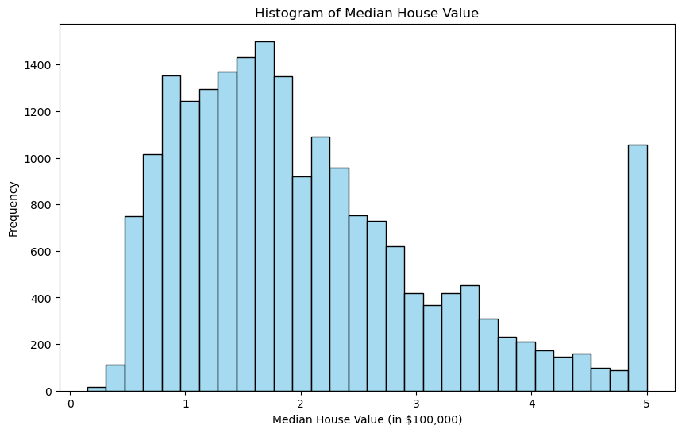

```python
plt.figure(figsize=(10, 6))
sb.histplot(housing_df['target'], bins=30, color='skyblue', edgecolor='black')
plt.title('Histogram of Median House Value')
plt.xlabel('Median House Value (in $100,000)')
plt.ylabel('Frequency')
plt.show()
```

We can see that the median house value in california is normally distributed around $175,0000 heavily skewed to the right, however theres a very large concentration of houses in the $500,000 dollar range, far away from the previously established distribution.

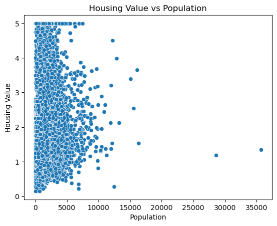

```python
sb.scatterplot(data = housing_df,x='Population', y='target', palette= 'mako')
plt.ylabel('Housing Value')
plt.xlabel('Population')
plt.title("Housing Value vs Population")
```

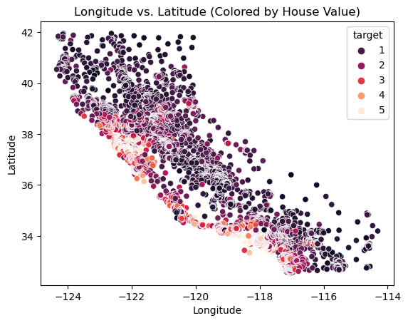

```python
sb.scatterplot(data=housing_df, x='Longitude', y='Latitude', hue='target', palette='rocket')
plt.title('Longitude vs. Latitude (Colored by House Value)')
plt.xlabel('Longitude')
plt.ylabel('Latitude')
```

Our dataset is showing in this plot that longitude and latitude are inversely correlated. i,e: when longitude increases, lattitude decreases.

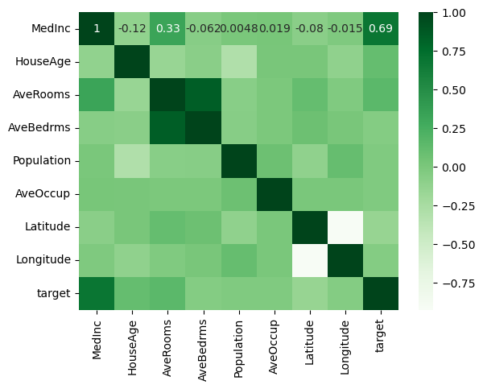

```python
sb.heatmap(housing_df.corr(),annot=True,cmap="Greens")
```

changed color from example for easier visualization.

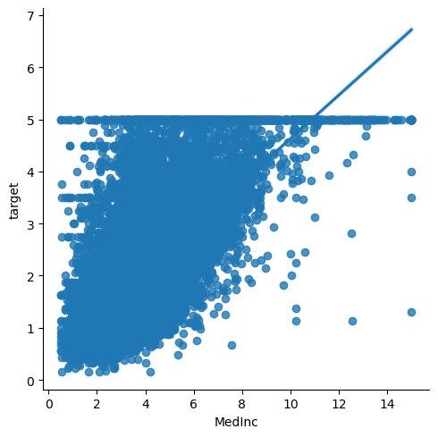

```python
plt.figure(figsize=(10, 6))
sb.lmplot(data=housing_df, x='MedInc', y='target')
```

Median income and housing value are linearly positively correlated

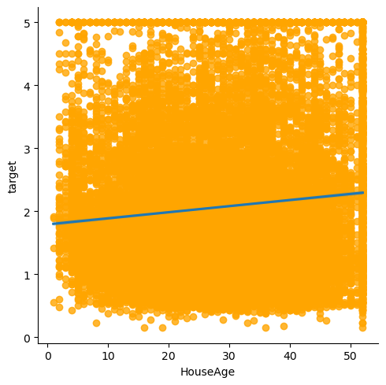

```python
plt.figure(figsize=(10, 6))
sb.lmplot(data=housing_df, x='HouseAge', y='target',scatter_kws={'color': 'orange'})
```

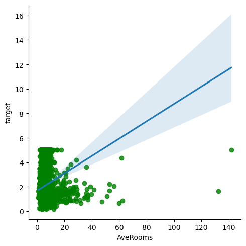

```python
plt.figure(figsize=(10, 6))
sb.lmplot(data=housing_df, x='AveRooms', y='target',scatter_kws={'color': 'green'})
```

Average room and housing value are correlated positively, which our heatmap confirms as well.

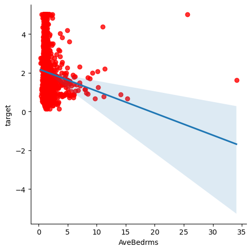

```python
plt.figure(figsize=(10, 6))
sb.lmplot(data=housing_df, x='AveBedrms', y='target',scatter_kws={'color': 'red'})
```

Average bedrooms is lightly negatively correlated with housing value. However we can see from this plot we can see a few outliers in very expensive homes that have much more bedrooms.

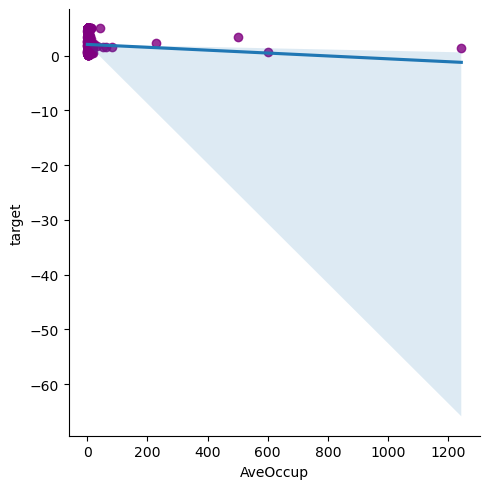

```python
plt.figure(figsize=(10, 6))
sb.lmplot(data=housing_df, x='AveOccup', y='target',scatter_kws={'color': 'purple'})
```

average occupancy for houses seems to have an extremely weak negative correlation with housing value.

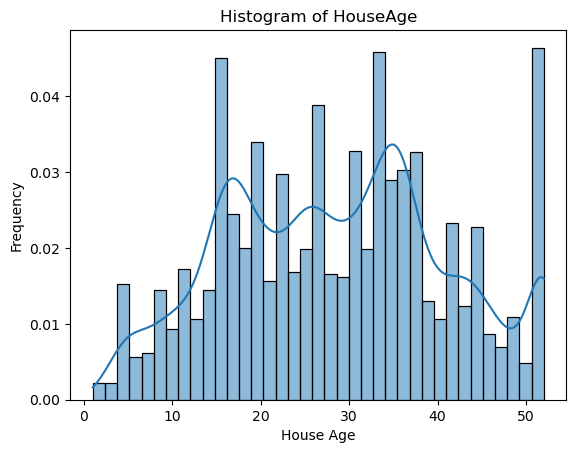

```python
sb.histplot(housing_df['HouseAge'], kde=True, stat='density')
plt.title('Histogram of HouseAge')
plt.xlabel('House Age')
plt.ylabel('Frequency')
plt.show()
```

We can see that relatively speaking, housing age is normally distributed with the center at 25 years, however, there are many outliers with high amounts of houses specifically at 15 years, 25 years, and 50+ years.

Question pdf asks for relative frequency in image.

```python
from sklearn.model_selection import train_test_split
from sklearn.preprocessing import StandardScaler
from sklearn.neural_network import MLPRegressor
from sklearn.metrics import r2_score
```

```python
scaler = StandardScaler()

scaled_data = scaler.fit_transform(housing_df)

scaled_df = pd.DataFrame(scaled_data, columns=housing_df.columns)
```

```python
X = scaled_df.drop(columns=['target'])
Y = scaled_df['target']

X_train, X_test, y_train, y_test = train_test_split(X, Y, test_size=0.3)
#split
```

```python
#neural network
mlp_regressor = MLPRegressor(hidden_layer_sizes=(130, 64, 32, 16), activation='relu')
mlp_regressor.fit(X_train, y_train)
```

```
MLPRegressor(hidden_layer_sizes=(130, 64, 32, 16))
```

```python
predictions = mlp_regressor.predict(X_test) #predict using scaled test x
```

```python
r2 = r2_score(y_test, predictions) #now we compare our predictions with our real y
print("R2 Score:", r2)
```

```
R2 Score: 0.782285826100545
```

Our model performed very well with roughly 80% accuracy.

```python
mlp_regressor = MLPRegressor(hidden_layer_sizes=(64, 32, 16, 8), activation='relu')
mlp_regressor.fit(X_train, y_train)
predictions = mlp_regressor.predict(X_test)
r2 = r2_score(y_test, predictions)
print("R2 Score:", r2)
```

```
R2 Score: 0.7832323655075168
```

Reducing our layer sizes by half increases our r squared value.

```python
mlp_regressor = MLPRegressor(hidden_layer_sizes=(32, 16, 8,4), activation='relu')
mlp_regressor.fit(X_train, y_train)
predictions = mlp_regressor.predict(X_test)
r2 = r2_score(y_test, predictions)
print("R2 Score:", r2)
```

```
R2 Score: 0.7960998976679812
```

```python
mlp_regressor = MLPRegressor(hidden_layer_sizes=(64,32,16,8,4,2), activation='relu')
mlp_regressor.fit(X_train, y_train)
predictions = mlp_regressor.predict(X_test)
r2 = r2_score(y_test, predictions)
print("R2 Score:", r2)
```

```
R2 Score: 0.7858891408551953
```

```python
iris_df
```

[output not shown]

150 rows × 5 columns

```python
iris_df.describe()
```

[output not shown]

```python
iris_df.info()
```

```
<class 'pandas.core.frame.DataFrame'>
RangeIndex: 150 entries, 0 to 149
Data columns (total 5 columns):
 #   Column             Non-Null Count  Dtype
---  ------             --------------  -----
 0   sepal length (cm)  150 non-null    float64
 1   sepal width (cm)   150 non-null    float64
 2   petal length (cm)  150 non-null    float64
 3   petal width (cm)   150 non-null    float64
 4   target             150 non-null    int32
dtypes: float64(4), int32(1)
memory usage: 5.4 KB
```

```python
iris_df.isnull().sum()
```

```
sepal length (cm)    0
sepal width (cm)     0
petal length (cm)    0
petal width (cm)     0
target               0
dtype: int64
```

iris dataset looks good. no missing values. no null values. 150 datapoints.

```python
import numpy as np
iris_df['species'] = iris_df['target']
iris_df = iris_df.drop(columns=['target'])
```

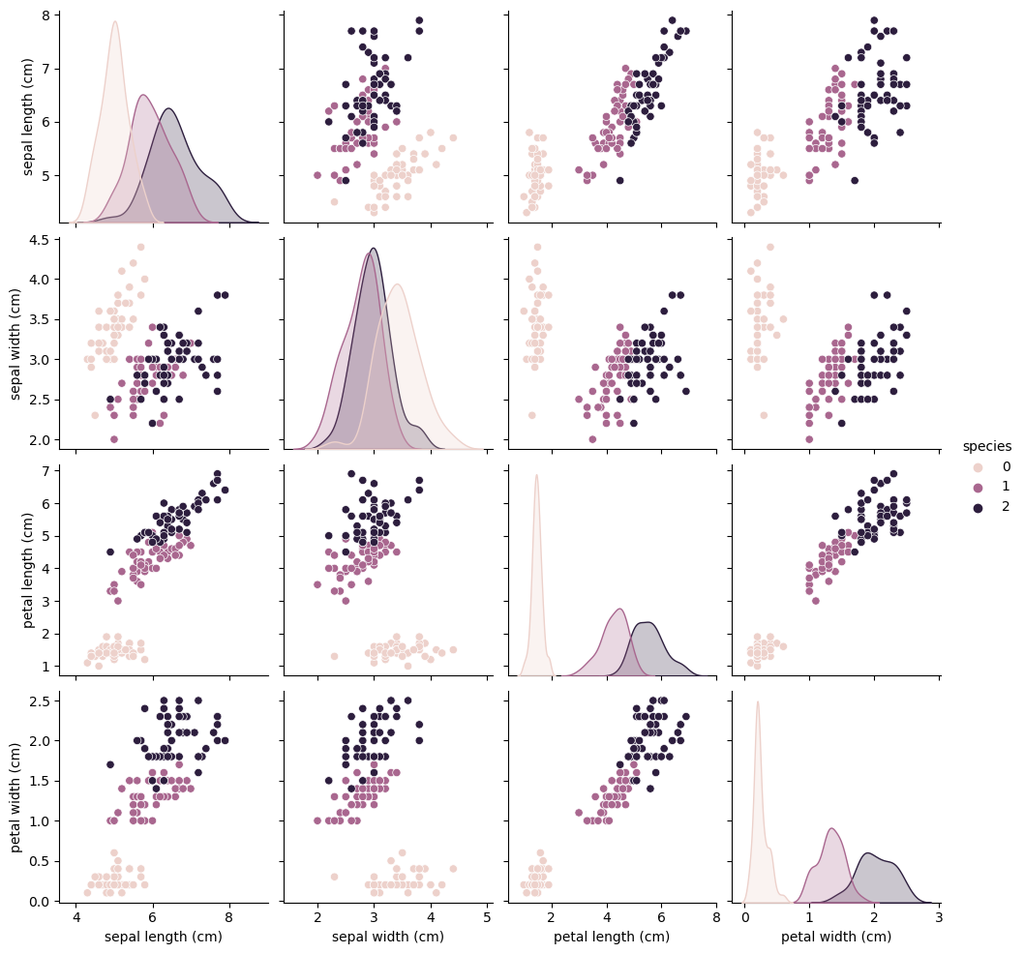

```python
sb.pairplot(iris_df, hue='species', diag_kind='kde')
```

we can the correlation between many of our variables using this pairplot which essentially does all the histogram relationship plotting without having to manually write out and label each individual plot.

```python
tempiris = iris_df.copy()
tempiris.rename(columns={'species': 'target'}, inplace=True)
iris_df
```

|  | sepal length (cm) | sepal width (cm) | petal length (cm) | petal width (cm) | species |
| --- | --- | --- | --- | --- | --- |
| 0 | 5.1 | 3.5 | 1.4 | 0.2 | 0 |
| 1 | 4.9 | 3.0 | 1.4 | 0.2 | 0 |
| 2 | 4.7 | 3.2 | 1.3 | 0.2 | 0 |
| 3 | 4.6 | 3.1 | 1.5 | 0.2 | 0 |
| 4 | 5.0 | 3.6 | 1.4 | 0.2 | 0 |
| ... | ... | ... | ... | ... | ... |
| 145 | 6.7 | 3.0 | 5.2 | 2.3 | 2 |
| 146 | 6.3 | 2.5 | 5.0 | 1.9 | 2 |
| 147 | 6.5 | 3.0 | 5.2 | 2.0 | 2 |
| 148 | 6.2 | 3.4 | 5.4 | 2.3 | 2 |
| 149 | 5.9 | 3.0 | 5.1 | 1.8 | 2 |

150 rows × 5 columns

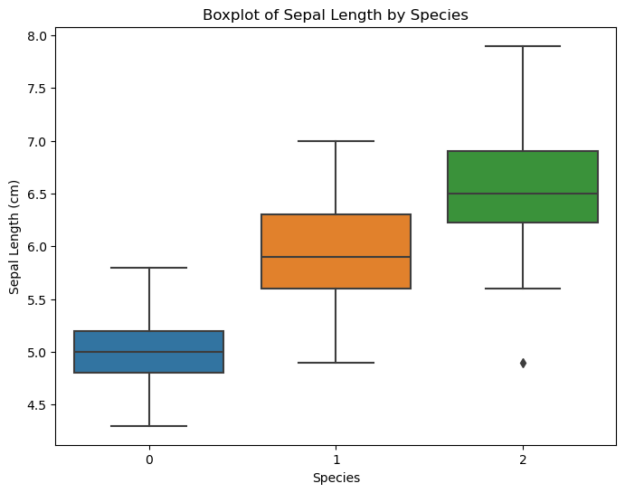

```python
plt.figure(figsize=(8, 6))
sb.boxplot(x='species', y='sepal length (cm)', data=iris_df)
plt.title('Boxplot of Sepal Length by Species')
plt.xlabel('Species')
plt.ylabel('Sepal Length (cm)')
plt.show()
```

it appears these 3 different species are strongly decided by average sepal length, as species 0 has the least, and species 2 has the most in terms of average sepal distribution

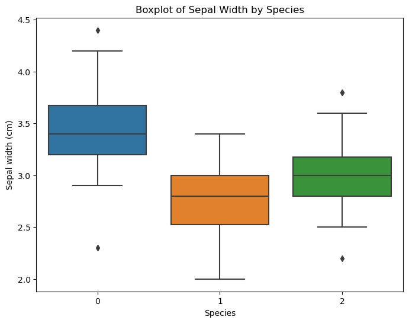

```python
#A boxplot of species on the x-axis and sepal width (cm) on the y-axis

#Create a boxplot
plt.figure(figsize=(8, 6))
sb.boxplot(x='species', y='sepal width (cm)', data=iris_df)
plt.title('Boxplot of Sepal Width by Species')
plt.xlabel('Species')
plt.ylabel('Sepal width (cm)')
plt.show()
```

in terms of width of sepal, it seems our numerical designation of species was not considered here.

species 0 has the largest average distribution with 2 following behind and 1 at the least.

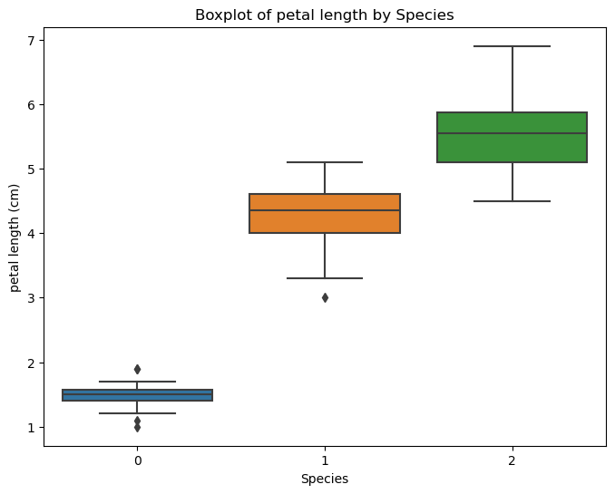

```python
#A boxplot of species on the x-axis and petal length (cm) on the y-axis
plt.figure(figsize=(8, 6))
sb.boxplot(x='species', y='petal length (cm)', data=iris_df)
plt.title('Boxplot of petal length by Species')
plt.xlabel('Species')
plt.ylabel('petal length (cm)')
plt.show()
```

Pedal length is very similary distributed to our sepal length, showing our species number is highly related to our length attributes.

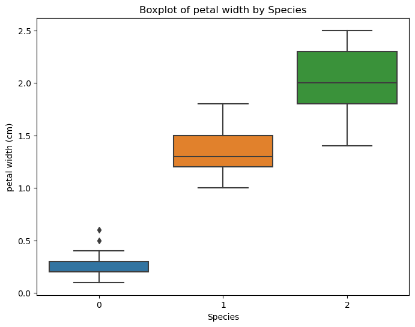

```python
#A boxplot of species on the x-axis and petal width (cm) on the y-axis
plt.figure(figsize=(8, 6))
sb.boxplot(x='species', y='petal width (cm)', data=iris_df)
plt.title('Boxplot of petal width by Species')
plt.xlabel('Species')
plt.ylabel('petal width (cm)')
plt.show()
```

petal width follows the same distribution of the other graphs, with 0 having the smallest petal width dist and 2 having the highest.

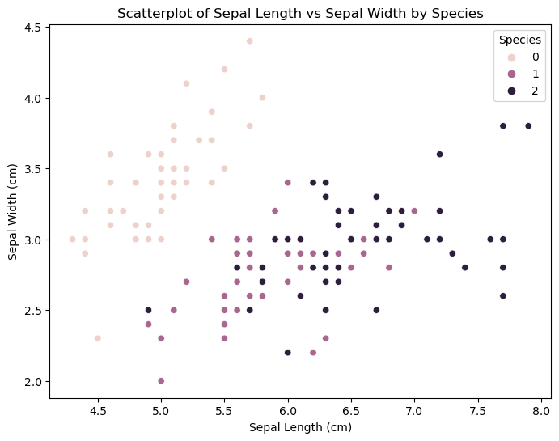

```python
plt.figure(figsize=(8, 6))
sb.scatterplot(x='sepal length (cm)', y='sepal width (cm)', hue='species', data=iris_df)
plt.title('Scatterplot of Sepal Length vs Sepal Width by Species')
plt.xlabel('Sepal Length (cm)')
plt.ylabel('Sepal Width (cm)')
plt.legend(title='Species')
plt.show()
```

Using sepal area (length and volume), we can see that all of species 0 have very simialr sepal dimensions as any other member of species 0, however, its also evident that species 1 and 2 are heavily intermixed and would be hard to differentiate on these attributes alone.

```python
iris_df
```

|  | sepal length (cm) | sepal width (cm) | petal length (cm) | petal width (cm) | species |
| --- | --- | --- | --- | --- | --- |
| 0 | 5.1 | 3.5 | 1.4 | 0.2 | 0 |
| 1 | 4.9 | 3.0 | 1.4 | 0.2 | 0 |
| 2 | 4.7 | 3.2 | 1.3 | 0.2 | 0 |
| 3 | 4.6 | 3.1 | 1.5 | 0.2 | 0 |
| 4 | 5.0 | 3.6 | 1.4 | 0.2 | 0 |
| ... | ... | ... | ... | ... | ... |
| 145 | 6.7 | 3.0 | 5.2 | 2.3 | 2 |
| 146 | 6.3 | 2.5 | 5.0 | 1.9 | 2 |
| 147 | 6.5 | 3.0 | 5.2 | 2.0 | 2 |
| 148 | 6.2 | 3.4 | 5.4 | 2.3 | 2 |
| 149 | 5.9 | 3.0 | 5.1 | 1.8 | 2 |

150 rows × 5 columns

```python
from sklearn.neural_network import MLPClassifier
from sklearn.metrics import accuracy_score


X = iris_df.drop(columns='species')
y = iris_df['species']

#scale the data
scaler = StandardScaler()

X_scaled = scaler.fit_transform(X)
```

```python
X_train, X_test, y_train, y_test = train_test_split(X_scaled, y, test_size=0.3)
```

```python
mlp_classifier = MLPClassifier(hidden_layer_sizes=(256,128,64,32), activation='relu')
```

```python
mlp_classifier.fit(X_train, y_train)
```

```
MLPClassifier(hidden_layer_sizes=(256, 128, 64, 32))
```

```python
predictions = mlp_classifier.predict(X_test)
```

```python
accuracy = accuracy_score(y_test, predictions)
accuracy
```

```
0.9555555555555556
```

```python
mlp_classifier = MLPClassifier(hidden_layer_sizes=(128,64,32,16), activation='relu')
mlp_classifier.fit(X_train, y_train)
predictions = mlp_classifier.predict(X_test)
accuracy = accuracy_score(y_test, predictions)
accuracy
```

```
0.9333333333333333
```

model performs worse if we make layers smaller

```python
from sklearn.metrics import confusion_matrix
cm = confusion_matrix(y_test, predictions)
```

[figure not shown]

```python
plt.figure(figsize=(8, 6))
sb.heatmap(cm, annot=True, cmap='Blues', fmt='g', cbar=False)
plt.title('Confusion Matrix')
plt.show()
```